# Eugene Morgan

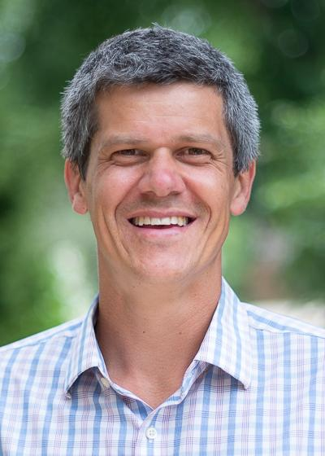

**Associate Head for Undergraduate Education**

**Associate Teaching Professor**

John and Willie Leone Family Department of Energy and Mineral Engineering  
Penn State University  
115 Hosler Building  
University Park, PA 16802-5000  
office: 814-863-1642  
eugene.morgan@psu.edu

### Research Interests

My primary research activities focus on developing Bayesian inversion strategies for extracting information from seismic survey data. In particular, I investigate the use of seismic attenuation in these inversion strategies because instrinsic attenuation is theoretically linked more strongly to the hydraulic properties of a formation (i.e., porosity, permeability, saturation) than velocity. The non-linearity and multimodality of the rock physics equations that model attenuation warrant stochastic inversion techniques, and a Bayesian framework allows a convenient expression of prior geologic knowledge, as well as the predictions, in a probabilistic way. These methods can achieve a better characterization of reservoirs in the exploration phase.

I am also interested in solving problems in the oil and gas industry using statistics, BIG data analytics, and machine learning. A large focus is on well production data, where my group is using time series statistics, geostatistics, and pattern recognition techniques to improve forecasting and operational decision support.

### Employment

- *John and Willie Leone Family Department of Energy and Mineral Engineering, Penn State* 2014-present
- Adjunct Faculty, *Duke University, Pratt School of Engineering & Department of Statistical Science* 2012-2014
- Visiting Assistant Professor, *Duke University, Department of Civil & Environmental Engineering* 2011-2012
- Research Fellow, *Statistical and Applied Mathmatical Sciences Institute* 2011-2012

### Education

- Ph.D., *Tufts University, Civil & Environmental Engineering* 2011
- M.S., *Tufts University, Civil & Environmental Engineering* 2008
- B.S., *U.C. Santa Cruz, Earth Sciences* 2005

### Courses Taught

- EME 210/PNG 397: Data Analytics for Energy Systems
- PNG 440: Formation Evaluation
- PNG 490: Introduction to Petroleum Engineering Design (capstone)
- PNG 566: Reservoir Characterization

### Other Activities

- Participant in the National Risk Assessment Partnership (NRAP) 2017-2022
- Scholarship Chair, *SPE Pittsburgh Section* 2014-Present
- Faculty Advisor, *Penn State SPE Student Chapter* 2014-2018